Feb 2, 2018

# 영양학과 반려동물

Posted in AnimalSci

## 영양학과 반려동물

반려 동물 뿐만이 아니라 모든 생명체가 건강하게 살기 위해서는 반드시 적절한 영양소가 공급되어야 합니다. 사전적인 의미에서 영양은 ‘생물이 살아가는 데 필요한 에너지와 몸을 구성하는 성분을 외부에서 섭취하여 소화, 흡수, 순환, 호흡, 배설을 하는 과정. 또는 그것을 위하여 필요한 성분’ 이라고 정의되어 있습니다. 조금 더 짧게 말하자면, **생명체가 살아가기 위해 몸 밖으로 부터 섭취하고 이용하는 것**이라 볼 수 있습니다.  
겨울잠을 자는 중이 아니라면, 대부분의 동물은 매일같이 **1)먹고 2)소화하고 3)이용하고 4)배출**하는 일들을 반복합니다. 누군가는 이 모든 과정이 당연하다고 생각할 수도 있겠지만 하나하나 자세히 들여다 보면 생각보다 매우 복잡한 일들이 일어나고 있습니다. 동물 체내에서 일어나는 생리적 작용들은 동물의 종류, 성장 단계와 성별 등에 따라서 다를 수 있으며, 각각의 영양소들은 동물의 생체 내에서 독립적으로 작용하기도 유기적으로 서로 관련되어 작용하기도 합니다.

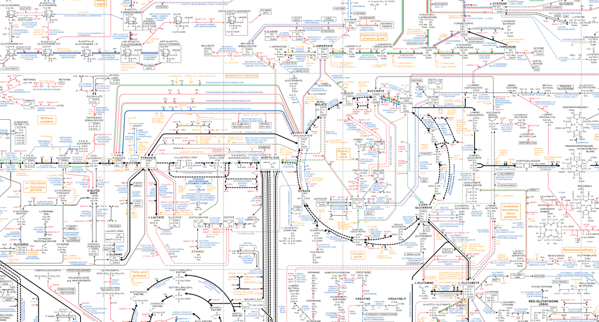

Roche Ltd. 에서 제공하는 [Metabolic pathway map](http://biochemical-pathways.com/#/map/1)의 일부분. 매우 혼란복잡하다…

이처럼 복잡하게 이루어 지는 여러가지 영양적인 현상을 연구하고 탐구하는 학문을 동물 영양학(animal nutrition)이라고 합니다.  
2018년 반려동물영양학 강의를 준비하면서 반려동물의 영양과 사양에 대한 교재가 비교적 많지 않다는 것을 깨닳았습니다. 본 연재에서는 강의준비하는김에동물 영양학의 기초를 차근차근 정리해보고자 합니다.

### [목차]반려동물 영양학

[1. Introduction–영양학과 반려동물](https://youngjunna.github.io/2018/02/02/CANF-Introduction/)

[2. 입/식도–Mouth/Esophagus](https://youngjunna.github.io/2018/02/05/CANF-Mouth)